# What the Pollsters Got Wrong: An Analysis of the 2016 Election Predictions

Courtney Sweeney

11-14-2025

# What the Pollsters Got Wrong: An Analysis of the 2016 Election Predictions

### A step-by-step guide to data wrangling using two datasets

The 2016 presidential election sent shock waves throughout the country. This wasn’t just because of the result, but because polls made it seem as though [Clinton would win in a landslide](https://www.cbsnews.com/news/2016-polls-president-trump-clinton-what-went-wrong/). For Democrats, understanding what went wrong during this campaign is incredibly important to both understanding their opposition and engineering campaigns that can win.

For pollsters, this data is also important so they can increase the accuracy of their polls in the future.

### The Datasets

The two datasets used in this tutorial are from the **dslabs** package. They are *polls_us_election_2016* and *results_us_election_2016*.

The *polls_us_election_2016* set includes information about 4208 polls that were conducted at various times leading up to the election. Every row includes a state, pollster, pollster grade, start and end dates, sample size, and poll numbers for every candidate.

The *results_us_election_2016* set includes the election results for every state. Every row includes a state, the elector votes, and the percentage of votes for each candidate.

## An Introduction to Data Wrangling

## 1. Set-Up

The first steps of data wrangling include loading packages and data sets. In R, packages that can be used for datawrangling include **tidyverse**, **dplyr**, **mdsr**, and **mosaic**.

To load data sets, store data from packages in variables (ex: polls <- polls_us_election_2016). If a data set is being imported, click “import” and copy and paste the code that is displayed in this pop-up window.

## 2. Cleaning the Data

To get data into a usable form, the data must first be cleaned. This requires multiple steps that depend on the type of data that is present.

### Select()

The **select()** function creates either a new database or replaces the old database (depending on assignment) with only the columns chosen by the user.

Here, the **select()** function uses “-” to denote that those columns are not selected. This was used because there were more columns being kept than being excluded.

Sometimes, datasets have extra information that is not needed by the user for their analysis. This is when **select()** is useful in data cleaning.

```r
hilary_trump <- select(polls, -population, -samplesize,
                       -rawpoll_mcmullin, -adjpoll_mcmullin,
                       -rawpoll_johnson, -adjpoll_johnson)

head(hilary_trump) #the head function is used to display the first few rows;
```

```
##   state  startdate    enddate
## 1  U.S. 2016-11-03 2016-11-06
## 2  U.S. 2016-11-01 2016-11-07
## 3  U.S. 2016-11-02 2016-11-06
## 4  U.S. 2016-11-04 2016-11-07
## 5  U.S. 2016-11-03 2016-11-06
## 6  U.S. 2016-11-03 2016-11-06
##                                                     pollster grade
## 1                                   ABC News/Washington Post    A+
## 2                                    Google Consumer Surveys     B
## 3                                                      Ipsos    A-
## 4                                                     YouGov     B
## 5                                           Gravis Marketing    B-
## 6 Fox News/Anderson Robbins Research/Shaw & Company Research     A
##   rawpoll_clinton rawpoll_trump adjpoll_clinton adjpoll_trump
## 1           47.00         43.00        45.20163      41.72430
## 2           38.03         35.69        43.34557      41.21439
## 3           42.00         39.00        42.02638      38.81620
## 4           45.00         41.00        45.65676      40.92004
## 5           47.00         43.00        46.84089      42.33184
## 6           48.00         44.00        49.02208      43.95631
```

```r
#a number of rows can be specified
```

### Na.omit()

The **na.omit()** function omits rows that have values with **NA** as the value. **NA** is R’s empty value, such as “none” or “null” in other languages.

Dealing with missing data is typically one of the first steps when cleaning data.

```r
#cleans the hilary_trump data
hilary_trump <- na.omit(hilary_trump)
```

### Filter()

Filtering data is used to select specific rows with specific values.

Here, the data is filtered based on the **state** variable. “!=” means that the rows are selected when the state is **NOT** “U.S.”.

The results that were contained in the other dataset are for every state and doesn’t include the U.S. as a whole, which is why the U.S. rows are being eliminated.

```r
#filters for non-US rows
hilary_trump <- filter(hilary_trump, state!="U.S.")
```

### Arrange()

The **arrange()** function is used to sort or rank data based on a specific variable. It can also be used with multiple variables.

Here, the data in *hilary_trump* is being sorted first by grade (in descending order) then enddate (also in descending order).

This is so that polls can be in order based on their pollster grade then by date to do tests about the best pollsters.

```r
hilary_trump <- arrange(hilary_trump, desc(grade),
                        desc(enddate))
```

### Distinct()

The **distinct()** function chooses rows based on a variable specified in the function. It only allows for one instance of every value for that variable.

Here, it is used to get the results from the highest rated pollsters that were the most recent for each state.

```r
#This finds distinct entries for every state
unique_ht = hilary_trump %>%
  distinct(state, .keep_all=TRUE) %>%
  arrange(state)

head(unique_ht)
```

```
##        state  startdate    enddate                                pollster
## 1    Alabama 2016-10-24 2016-11-06                                   Ipsos
## 2     Alaska 2016-10-11 2016-10-13                  Lake Research Partners
## 3    Arizona 2016-10-21 2016-10-24                     Monmouth University
## 4   Arkansas 2016-10-17 2016-11-06                                   Ipsos
## 5 California 2016-06-08 2016-07-02 Field Research Corporation (Field Poll)
## 6   Colorado 2016-09-29 2016-10-02                     Monmouth University
##   grade rawpoll_clinton rawpoll_trump adjpoll_clinton adjpoll_trump
## 1    A-           38.06         54.15        37.54023      53.69718
## 2    B+           36.00         37.00        36.93134      42.37487
## 3    A+           45.00         46.00        43.96341      47.57774
## 4    A-           38.14         53.35        37.15339      53.28384
## 5    A+           50.00         26.00        52.61833      29.79511
## 6    A+           49.00         38.00        49.30967      40.78545
```

This set could be used to see if these two variables can accurately predict a correct result for a candidate.

### Left_join()

**Joins** are used to connect two datasets or dataframes.

**Left_join()** is used to connect tables when all of the values from the first table must be kept, and the values from the second match the first.

The *results* dataset contains just one row for each state, so those results need to be applied to every column.

Joins also must be done on a variable. The variable chosen here is “state”, as that is what the two data sets have in common.

```r
#joined by state
joined1 <- left_join(unique_ht, results, by="state")
joined2 <- left_join(hilary_trump, results, by="state")

head(unique_ht, 2)
```

```
##     state  startdate    enddate               pollster grade rawpoll_clinton
## 1 Alabama 2016-10-24 2016-11-06                  Ipsos    A-           38.06
## 2  Alaska 2016-10-11 2016-10-13 Lake Research Partners    B+           36.00
##   rawpoll_trump adjpoll_clinton adjpoll_trump
## 1         54.15        37.54023      53.69718
## 2         37.00        36.93134      42.37487
```

```r
head(results, 2)
```

```
##        state electoral_votes clinton trump others
## 1 California              55    61.7  31.6    6.7
## 2      Texas              38    43.2  52.2    4.5
```

```r
head(joined1, 2)
```

```
##     state  startdate    enddate               pollster grade rawpoll_clinton
## 1 Alabama 2016-10-24 2016-11-06                  Ipsos    A-           38.06
## 2  Alaska 2016-10-11 2016-10-13 Lake Research Partners    B+           36.00
##   rawpoll_trump adjpoll_clinton adjpoll_trump electoral_votes clinton trump
## 1         54.15        37.54023      53.69718               9    34.4  62.1
## 2         37.00        36.93134      42.37487               3    36.6  51.3
##   others
## 1    3.6
## 2   12.2
```

In the final data set, the information from results is added onto the end of the row for each state. Each row begins with the information from the original dataset (startdate, pollster, etc) then finishes with the electoral votes and actual percentages.

There are multiple other join types that can be used: **right_join()**, **full_join()**, and **anti_join()**.

### Mutate()

The **mutate()** function creates new variables.

This is important when information needs to be created for each row from existing information. This can vary depending on the dataset.

```r
joined1 = joined1 %>%
  #declares the poll winner, adds a variable that contains that information
  mutate(poll_winner = if_else(adjpoll_clinton>adjpoll_trump,
                               "Clinton", "Trump")) %>%

  #does the same as above, but with the actual winner
  mutate(winner = if_else(clinton>trump, "Clinton", "Trump")) %>%

  #determines if the winner was correct
  mutate(correct = if_else(poll_winner==winner, TRUE, FALSE))

joined2 = joined2 %>%
  mutate(poll_winner = if_else(adjpoll_clinton>adjpoll_trump,
                               "Clinton", "Trump")) %>%
  mutate(winner = if_else(clinton>trump, "Clinton", "Trump")) %>%
  mutate(correct = if_else(poll_winner==winner, TRUE, FALSE)) %>%

  #This next section determines the "direction" of the poll and the winner.
  #If the winner is correct, then the value is "true".
  #If the value is "CT", then Clinton was predicted and Trump won. If
  #it was "TC", Trump was predicted and Hilary won.

  mutate(dir_winner = case_when(poll_winner==winner~"TRUE",
                              poll_winner=="Clinton"&winner=="Trump"~"CT",
                              poll_winner=="Trump"&winner=="Clinton"~"TC")) %>%

  #This adds a variable with the error found for Clinton's
  #polling and actual results.
  #The absolute value is used to standardize it.

  mutate(clinton_error = abs(adjpoll_clinton-clinton)) %>%
  #This does the same for Trump
  mutate(trump_error = abs(adjpoll_trump-trump))
```

## 3. Organizing the Data

The next section contains various functions from above in order to continue to organize the data.

Now that the data is organized and cleaned into a few different datasets, it can be manipulated to get more specific information.

```r
#This tallies the variable "dir_winner" from joined2 to see
#which way the pollsters typically predicted the results
tally(~joined2$dir_winner)
```

```
## joined2$dir_winner
##   CT   TC TRUE <NA>
##  504  101 2327   29
```

It is shown here that while the majority of polls were correct, if the polls were wrong, they overwhelmingly picked Clinton where Trump won.

```r
joined2 <- na.omit(joined2) #cleans data
#filters for states that predicted Clinton would win when Trump won
ct_wrong <- filter(joined2, dir_winner == "CT")
tally(~ct_wrong$state) #tallies the data
```

```
## ct_wrong$state
##         Alaska        Arizona       Arkansas        Florida        Georgia
##              4             19              1             77              4
##        Indiana           Iowa         Kansas       Kentucky       Michigan
##              5             20             15              1             70
##       Missouri        Montana       Nebraska North Carolina           Ohio
##             13              3              1             62             41
##   Pennsylvania   South Dakota           Utah      Wisconsin
##             97              1              3             67
```

Through these functions, it is very clear which states were consistently predicted incorrectly. Pennsylvania, Michigan, and Wisconsin were three of the states that have the highest amount of incorrect Clinton picks. These three states also happen to be swing states, meaning they can go either Democratic or Republican in any given election.

```r
#filters for some of the states with the highest frequency of Clinton
#prediction when Trump won all of them
wrong_swings <- filter(ct_wrong, state %in% c("Pennsylvania",
                                              "Iowa", "Florida",
                                              "North Carolina",
                                              "Michigan", "Ohio", "Wisconsin"))

#filters for the three swing states mentioned before
swings <- filter(joined2, state %in% c("Pennsylvania", "Michigan","Wisconsin"))

#arranges the swing states by state and then in descending order by date
wrong_swings <- arrange(wrong_swings, state, desc(enddate))

head(wrong_swings, 5)
```

```
##     state  startdate    enddate                                 pollster grade
## 1 Florida 2016-11-01 2016-11-07                             SurveyMonkey    C-
## 2 Florida 2016-11-03 2016-11-06                    Quinnipiac University    A-
## 3 Florida 2016-10-31 2016-11-06                                    Ipsos    A-
## 4 Florida 2016-11-02 2016-11-06 Rasmussen Reports/Pulse Opinion Research    C+
## 5 Florida 2016-11-05 2016-11-06           Opinion Savvy/InsiderAdvantage    C-
##   rawpoll_clinton rawpoll_trump adjpoll_clinton adjpoll_trump electoral_votes
## 1           47.00         45.00        45.59190      44.32744              29
## 2           46.00         45.00        46.44315      43.93999              29
## 3           47.66         46.77        47.61940      46.50841              29
## 4           47.00         45.00        47.55885      45.13673              29
## 5           48.40         46.40        47.37976      45.68637              29
##   clinton trump others poll_winner winner correct dir_winner clinton_error
## 1    47.8    49    3.2     Clinton  Trump   FALSE         CT       2.20810
## 2    47.8    49    3.2     Clinton  Trump   FALSE         CT       1.35685
## 3    47.8    49    3.2     Clinton  Trump   FALSE         CT       0.18060
## 4    47.8    49    3.2     Clinton  Trump   FALSE         CT       0.24115
## 5    47.8    49    3.2     Clinton  Trump   FALSE         CT       0.42024
##   trump_error
## 1     4.67256
## 2     5.06001
## 3     2.49159
## 4     3.86327
## 5     3.31363
```

### Group_by() & Summarize()

The **group_by()** function is typically used with a summarizing function.

Here, it is used with **summarize()**. The **summarize()** function is used with other functions like **mean()**. **Mean()** gets the average of a variable.

In this function, **group_by()** groups by state, then the average error for each candidate for each state is found.

```r
wrong_swings_error = wrong_swings %>%
  group_by(state) %>%
  summarize(avg_error_trump = mean(trump_error),
            avg_error_clinton = mean(clinton_error))

head(wrong_swings_error, 3)
```

```
## # A tibble: 3 × 3
##   state    avg_error_trump avg_error_clinton
##   <chr>              <dbl>             <dbl>
## 1 Florida             4.27              1.34
## 2 Iowa               10.6               2.51
## 3 Michigan            7.40              3.39
```

This showcases which states had the highest average errors.

### Pivot()

The **pivot()** function changes the format of the dataframe.

A **long** dataset has values that do repeat in the first column.

A **wide** dataset does not repeat values in the first column.

Depending on the situation, both can be useful. Here, the pivots are to create graphs. Graphs often use levels of variables or factors to display information.

To pivot_longer, like it is done here, follow this format:

long_df <- pivot_longer(df, cols=2:4, names_to=“Name”, values_to=“Amount”)

- cols = columns to be transformed into one column
- names_to = the title of the column being created
- values_to = the new column created with the values originally in every column

```r
#pivoting wrong_swings_error to a long format from wide
wrong_swings_error_long <- pivot_longer(wrong_swings_error,
                                        cols=2:3, names_to="Candidate",
                                        values_to="error")

#pivoting wrong_swings to a long format from wide
wrong_swings_long <- pivot_longer(wrong_swings, cols=18:19,
                                  names_to="candidate", values_to="error")

#selecting certain columns
wrong_swings_long <- select(wrong_swings_long, state, startdate,
                            enddate, pollster, grade, candidate, error)

head(wrong_swings_error, 4)
```

```
## # A tibble: 4 × 3
##   state          avg_error_trump avg_error_clinton
##   <chr>                    <dbl>             <dbl>
## 1 Florida                   4.27              1.34
## 2 Iowa                     10.6               2.51
## 3 Michigan                  7.40              3.39
## 4 North Carolina            5.88              1.24
```

```r
head(wrong_swings_error_long, 4)
```

```
## # A tibble: 4 × 3
##   state   Candidate         error
##   <chr>   <chr>             <dbl>
## 1 Florida avg_error_trump    4.27
## 2 Florida avg_error_clinton  1.34
## 3 Iowa    avg_error_trump   10.6
## 4 Iowa    avg_error_clinton  2.51
```

In the first dataframe, Florida only gets one row. In the second, it gets two. This is because one gives the candidate for the result, while the other gives both errors in the row for each state.

## 4. Final Changes

These are the final changes to prepare for data visualization.

```r
#this filters for polls from Pennsylvania that predicted Clinton won
penn <- filter(wrong_swings_long, state %in% c("Pennsylvania"))

swings <- swings %>%  #This renames the column to State for usage in the graph
  rename(State = state)

#this stores the actual results in a data frame to put on the graph
actual_results <- data.frame(
  x = c(47.5, 47.2, 48.6),
  y = c(47.3, 46.5, 47.9),
  State=c("Michigan", "Wisconsin", "Pennsylvania")
)
```

## 5. Visualization

### Scatterplot of Swing States

On the graph, there is a line with a slope of 1. Above this line signifies a “Clinton” win prediction, while below signifies a “Trump” win prediction. The majority of the points on this graph are above the line, signifying “Clinton” predictions.

The actual results are signified in the same color as the polling results but with a black outline. All three fall under the line, as all three states ended up voting for Trump.

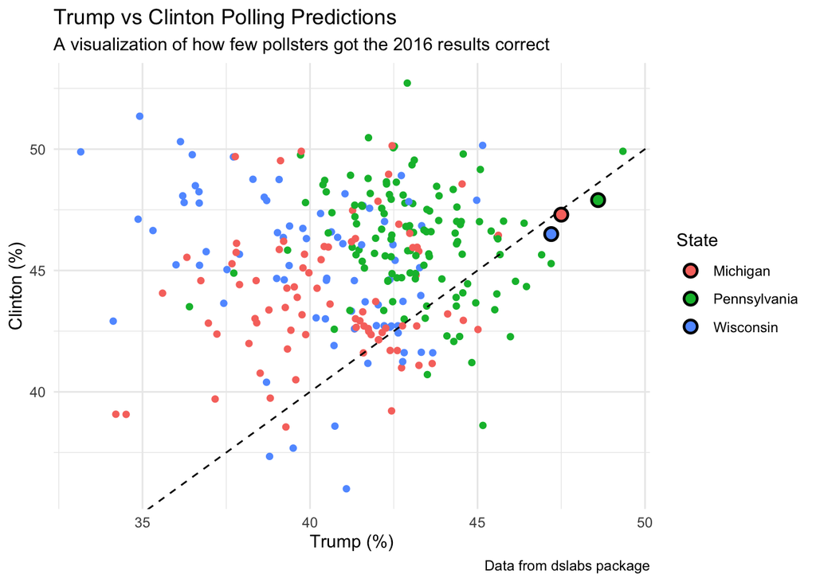

```r
ggplot(swings, aes(x=adjpoll_trump, y=adjpoll_clinton)) +geom_point(aes(color=State)) + geom_abline(intercept = 0, slope = 1, linetype="dashed") + geom_point(data=actual_results, aes(x=x, y=y, fill=State), shape = 21, size=3, stroke=1.2, color="black") + theme_minimal() + labs (x="Trump (%)", y="Clinton (%)", title="Trump vs Clinton Polling Predictions", subtitle="A visualization of how few pollsters got the 2016 results correct", caption="Data from dslabs package")
```

https://stackoverflow.com/questions/36541086/adding-an-extra-point-in-a-ggplot2-graph https://ggplot2.tidyverse.org/reference/geom_point.html

From this graph, we can gather that pollsters were overwhelmingly wrong about Michigan, Pennsylvania, and Wisconsin in particular.

If there was more information about the polling conducted to yield such inaccurate results, it would be very useful to see what factors may have contributed to this so that pollsters don’t make similar errors.

While it would be impossible for every poll to yield the correct results, there should be improvement so that there isn’t such a large error as shown here.

### Histogram of Polling Error

This graph shows the frequency of different errors between the polls that took place in Pennsylvania that predicted the election wrong. Since Trump won Pennsylvania, all of the results are from polls that incorrectly predicted Clinton would win.

While polls that correctly predicted Trump winning would also have an error, this focuses on only polls that completely got it wrong.

For Clinton, the error is how many points she was overestimated by. For Trump, the error is how many points he was underestimated by.

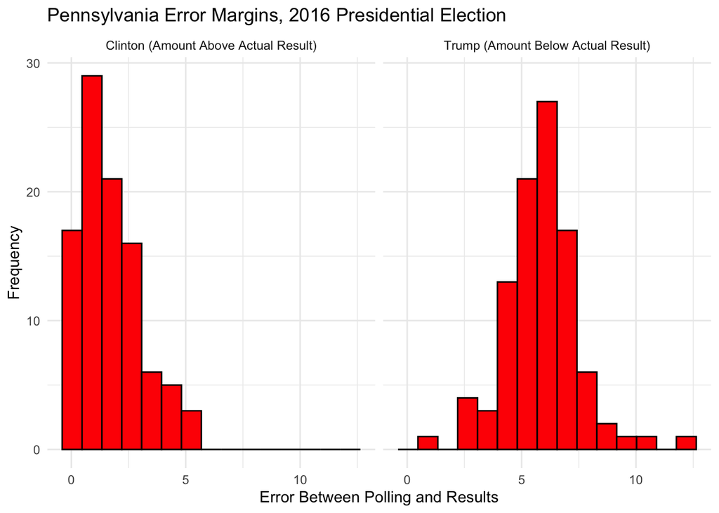

```r
ggplot(penn, aes(x=error)) + geom_histogram(fill="red", color="black", bins=15) + facet_wrap(~candidate, labeller=as_labeller(c("clinton_error"="Clinton (Amount Above Actual Result)", "trump_error"="Trump (Amount Below Actual Result)"))) + labs(y="Frequency", x="Error Between Polling and Results", title="Pennsylvania Error Margins, 2016 Presidential Election")+theme_minimal()
```

What this graph shows is that the error surrounding Trump was normally distributed, with the center at around 6 or 7. This means that Trump was underestimated by typically around 6 or 7 points. This is a substantial difference between polling and actual results.